# Capstone Exercise

Peter Olsoy

April 28, 2015

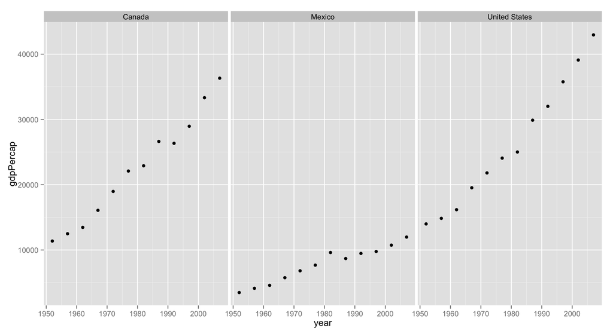

All three countries show exponential trends in GPD per capita over the given time frame. Canada and the United States start in relatively the same place and end with similar GDP. However, Mexico started far lower and is only now reaching where the USA (and Canada) were at during the start of these records. Funny enough, the order of plots gives a possible future continuation of Mexico’s growth into where the United States was in the past.

| continent | meanLifeExp | minLifeExp | maxLifeExp |
| --- | --- | --- | --- |
| Africa | 54.80604 | 39.613 | 76.442 |
| Americas | 73.60812 | 60.916 | 80.653 |
| Asia | 70.72848 | 43.828 | 82.603 |
| Europe | 77.64860 | 71.777 | 81.757 |
| Oceania | 80.71950 | 80.204 | 81.235 |

Africa has the consistently lowest life expectancy for mean, min, and max. Asia has the largest range, with almost as low of a minimum as Africa, but a much higher maximum – the highest of all the continents. Oceania has the highest mean and min, but that is being pulled only from Australia and New Zealand, so is rather uninformative. Europe has many more countries, but has a minimum of 71.8 years, suggesting a very high standard of living. The Americas is somewhere in the middle, most likely due to grouping both North America (more developed) with South America (less developed, poorer).

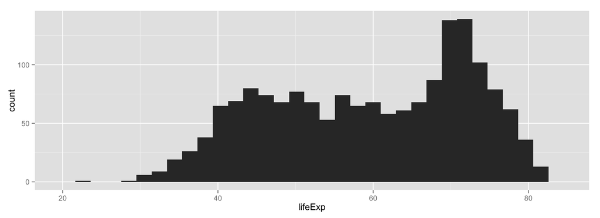

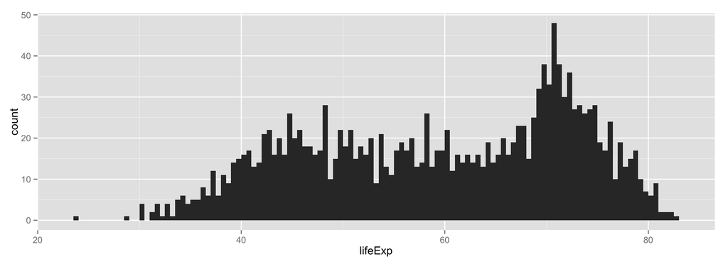

A larger binwidth results in a smoother histogram, while a smaller binwidth results in a noiser histogram with more detailed peaks.